# Decision Making with Sentiment Analysis in R

From Social Media Noise to Managerial Action

Author

Affiliation

Mustafa Asım Ruhi

Fresenius University of Applied Sciences

Published

June 2, 2026

Abstract

This handout explains how sentiment analysis can support managerial decision-making. It introduces the basic idea of sentiment analysis, presents a reproducible R workflow, and demonstrates how airline-related tweets can be transformed into decision-relevant insights. The example uses tidyverse and tidytext to clean, tokenize, visualize, and interpret customer feedback.

- **Student:** Mustafa Asım Ruhi
- **Student number:** 401190044
- **Course:** Data Analysis for Decision-Making
- **University:** Fresenius University of Applied Sciences
- **Email:** ruhi.mustafa@stud.hs-fresenius.de

## 0.1 Online Access

**NoteAccess the Handout**

[figure not shown]

- **Handout:** https://masimruhi.github.io/dadm/index.html
- **Presentation:** https://masimruhi.github.io/dadm/presentation.html
- **Repository:** https://github.com/masimruhi/dadm

# 1 Introduction

Modern companies receive large amounts of customer feedback through social media, online reviews, support chats, and survey comments. Much of this feedback is unstructured text, which means that it cannot be analysed as directly as numerical variables such as sales, prices, or ratings. Sentiment analysis helps convert this kind of text into structured information that can support decision-making (Liu, 2012; Pang & Lee, 2008).

This handout focuses on a practical question: How can customer tweets be transformed into decision-relevant insights for airline management? The example uses airline-related tweets and demonstrates a reproducible workflow in R. The goal is not only to classify text as positive or negative, but to connect the result to managerial action.

# 2 What is Sentiment Analysis?

Sentiment analysis is a text analysis method that identifies emotional orientation in written language. In a simple form, the method classifies text as positive, negative, or neutral. More advanced applications can detect emotions, topics, intensity, or changes over time. In business contexts, sentiment analysis is commonly used to monitor customer satisfaction, brand reputation, product feedback, and service quality.

A typical workflow includes importing text data, cleaning it, splitting the text into smaller units such as words, removing irrelevant words, matching words with sentiment dictionaries, and summarising the results. In R, packages such as `tidyverse` and `tidytext` make this workflow relatively accessible and reproducible (Silge & Robinson, 2017; Wickham et al., 2023).

# 3 Why is it Relevant for Decision-Making?

Decision-makers often need to identify which problems deserve attention first. When feedback is scattered across thousands of tweets, manual reading becomes slow and inconsistent. Sentiment analysis can quickly summarize the emotional tone of customer comments and highlight repeated sources of dissatisfaction.

For example, if an airline receives many negative comments about delayed flights, management can improve delay communication, operational punctuality, or compensation processes. If most negative comments refer to customer service, management may prioritize staff training, support capacity, or service recovery. The value of sentiment analysis therefore depends on whether the results lead to concrete decisions.

There are different approaches to sentiment analysis, including lexicon-based methods, machine learning methods, transformer-based models, and hybrid approaches. This project focuses on a lexicon-based approach because it is transparent, reproducible in RStudio, and suitable for a short live demonstration.

# 4 Data and Example Context

The example uses the Twitter US Airline Sentiment dataset, which contains 14,640 airline-related tweets. The dataset includes the tweet text, the airline, a sentiment label, and, for negative tweets, a reason for the negative sentiment.

The following code summarizes the distribution of the provided sentiment labels.

```r
tweets |>
  count(airline_sentiment) |>
  mutate(share = scales::percent(n / sum(n))) |>
  knitr::kable()
```

*Table 1. Overall sentiment distribution in the airline tweet dataset.*

| airline_sentiment | n | share |
| --- | --- | --- |
| negative | 9178 | 62.7% |
| neutral | 3099 | 21.2% |
| positive | 2363 | 16.1% |

This structure makes the dataset useful for a classroom example. It contains both unstructured text and already labelled sentiment categories. The labels make it possible to compare simple visual summaries with a dictionary-based text mining approach.

# 5 Preparing Data in R

The first step is to import and clean the data. The function `clean_names()` from the `janitor` package standardises variable names. The `select()` function keeps only the variables that are relevant for the analysis.

```r
url <- paste0(
  "https://raw.githubusercontent.com/",
  "ruchitgandhi/Twitter-Airline-Sentiment-Analysis/",
  "master/Tweets.csv"
)

tweets <- readr::read_csv(url, show_col_types = FALSE) |>
  janitor::clean_names() |>
  select(
    airline_sentiment,
    negativereason,
    airline,
    retweet_count,
    text,
    tweet_created
  )
```

This step follows an important principle in reproducible data analysis: the workflow should be written in code so that the analysis can be repeated or adjusted later (Huber, 2025).

# 6 Descriptive Analysis of Sentiment

Before applying text mining, it is useful to examine the provided sentiment labels. The following figure shows how negative, neutral, and positive tweets are distributed across airlines.

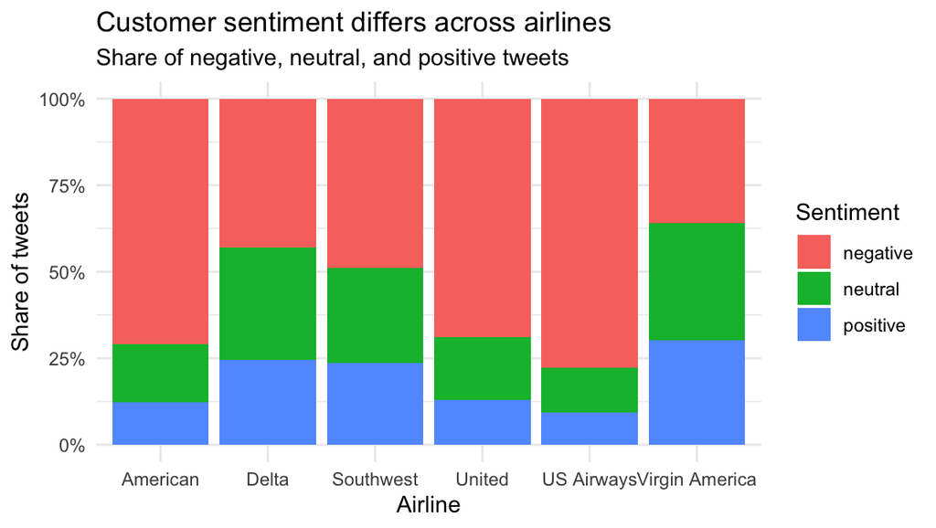

```r
sentiment_by_airline <- tweets |>
  count(airline, airline_sentiment) |>
  group_by(airline) |>
  mutate(share = n / sum(n)) |>
  ungroup()

ggplot(sentiment_by_airline, aes(x = airline, y = share, fill = airline_sentiment)) +
  geom_col(position = "fill") +
  scale_y_continuous(labels = scales::percent) +
  labs(
    title = "Customer sentiment differs across airlines",
    subtitle = "Share of negative, neutral, and positive tweets",
    x = "Airline",
    y = "Share of tweets",
    fill = "Sentiment"
  ) +
  theme_minimal()
```

*Figure 1. Sentiment distribution by airline.*

The figure is useful for decision-making because it allows managers to compare airlines quickly. However, a sentiment label alone is not enough. A manager also needs to understand why customers are dissatisfied.

# 7 Negative Sentiment and Business Problems

After the general sentiment overview, the analysis focuses on negative tweets. The dataset contains a variable that explains the reason behind many negative tweets. This is important because every negative reason can point to a different business problem.

```r
negative_reasons <- tweets |>
  filter(airline_sentiment == "negative", !is.na(negativereason)) |>
  count(negativereason, sort = TRUE)

negative_reasons |>
  slice_max(n, n = 8) |>
  knitr::kable()
```

*Table 2. Main negative reasons in customer tweets.*

| negativereason | n |
| --- | --- |
| Customer Service Issue | 2910 |
| Late Flight | 1665 |
| Can’t Tell | 1190 |
| Cancelled Flight | 847 |
| Lost Luggage | 724 |
| Bad Flight | 580 |
| Flight Booking Problems | 529 |
| Flight Attendant Complaints | 481 |

The same result can also be visualised as a bar chart. This makes it easier to identify which business problems should receive attention first.

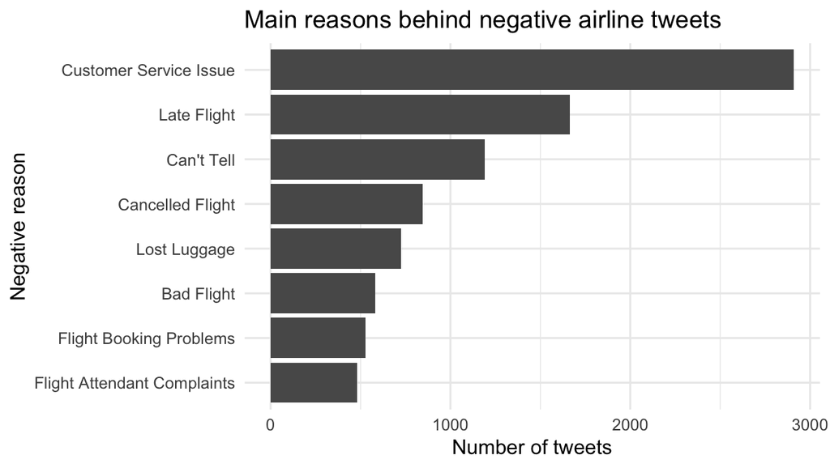

```r
negative_reasons |>
  slice_max(n, n = 8) |>
  ggplot(aes(x = reorder(negativereason, n), y = n)) +
  geom_col() +
  coord_flip() +
  labs(
    title = "Main reasons behind negative airline tweets",
    x = "Negative reason",
    y = "Number of tweets"
  ) +
  theme_minimal()
```

*Figure 2. Most frequent negative reasons behind airline-related complaints.*

The results connect sentiment analysis to operational decision-making. Negative comments are not random; they often refer to service issues, delayed flights, cancelled flights, baggage problems, or booking problems. Each category suggests a different managerial response.

# 8 Text Mining and Tokenization

A central step in text mining is tokenization. Tokenization means splitting text into smaller units. In this example, each tweet is split into individual words. Stop words such as common function words are removed because they usually do not provide much meaning for sentiment analysis.

```r
tweets_words <- tweets |>
  mutate(tweet_id = row_number()) |>
  select(tweet_id, airline, airline_sentiment, text) |>
  tidytext::unnest_tokens(word, text) |>
  anti_join(tidytext::stop_words, by = "word") |>
  filter(
    stringr::str_detect(word, "[a-z]"),
    !stringr::str_detect(word, "^http"),
    !stringr::str_detect(word, "^t.co")
  )

tweets_words |>
  count(word, sort = TRUE) |>
  head(10)
```

*Table 3. Most frequent words after tokenization and stop-word removal.*

| word | n |
| --- | --- |
| united | 4154 |
| flight | 3926 |
| usairways | 3051 |
| americanair | 2962 |
| southwestair | 2457 |
| jetblue | 2366 |
| cancelled | 1064 |
| service | 965 |
| time | 791 |
| customer | 752 |

The tidy approach is useful because the result is a table in which each row is one word from one tweet. This format can be filtered, counted, joined with dictionaries, and visualised using familiar `dplyr` and `ggplot2` functions.

# 9 Lexicon Choices for Sentiment Analysis

Lexicon-based sentiment analysis can use different dictionaries. In this project, the Bing lexicon is used, but other lexicons such as AFINN and NRC are also available.

| Lexicon | Output type | What it shows | Why / when useful |
| --- | --- | --- | --- |
| Bing | Positive / negative categories | Whether matched words are positive or negative | Simple, transparent, and suitable for a short RStudio demonstration |
| AFINN | Numerical sentiment score | Direction and intensity of sentiment | Useful when the strength of sentiment matters |
| NRC | Emotion categories | Emotions such as anger, fear, joy, sadness, and trust | Useful for richer emotional analysis |

In this handout, the Bing lexicon is used because it is simple, transparent, and easy to reproduce during a short presentation. It clearly shows which words are classified as positive or negative. Other lexicons could provide more detailed results, but Bing is the most suitable choice for demonstrating the basic logic of lexicon-based sentiment analysis.

# 10 Lexicon-Based Sentiment Analysis

A lexicon-based method uses a dictionary that assigns sentiment labels to words. In this example, the Bing lexicon is used through the `get_sentiments("bing")` function. Words from the tweets are matched with positive and negative words from the dictionary.

```r
word_sentiments <- tweets_words |>
  inner_join(
    tidytext::get_sentiments("bing"),
    by = "word"
  )

word_sentiments |>
  count(sentiment, sort = TRUE)
```

*Table 4. Positive and negative word counts using the Bing lexicon.*

| sentiment | n |
| --- | --- |
| negative | 7841 |
| positive | 3965 |

This method is transparent and easy to explain. However, it has limitations. It may miss sarcasm, context, negation, and domain-specific meanings.

The following code shows the most frequently matched positive and negative sentiment words.

```r
top_sentiment_words <- word_sentiments |>
  count(sentiment, word, sort = TRUE) |>
  group_by(sentiment) |>
  slice_max(n, n = 8) |>
  ungroup()

top_sentiment_words |>
  arrange(sentiment, desc(n))
```

*Table 5. Most frequent positive and negative sentiment words.*

| sentiment | word | n |
| --- | --- | --- |
| negative | delayed | 545 |
| negative | delay | 301 |
| negative | lost | 243 |
| negative | worst | 240 |
| negative | bad | 186 |
| negative | stuck | 171 |
| negative | miss | 160 |
| negative | issue | 153 |
| positive | love | 245 |
| positive | refund | 147 |
| positive | nice | 135 |
| positive | free | 132 |
| positive | awesome | 124 |
| positive | helpful | 102 |
| positive | amazing | 98 |
| positive | happy | 91 |

The presentation also uses the following figure to show frequent positive and negative words visually.

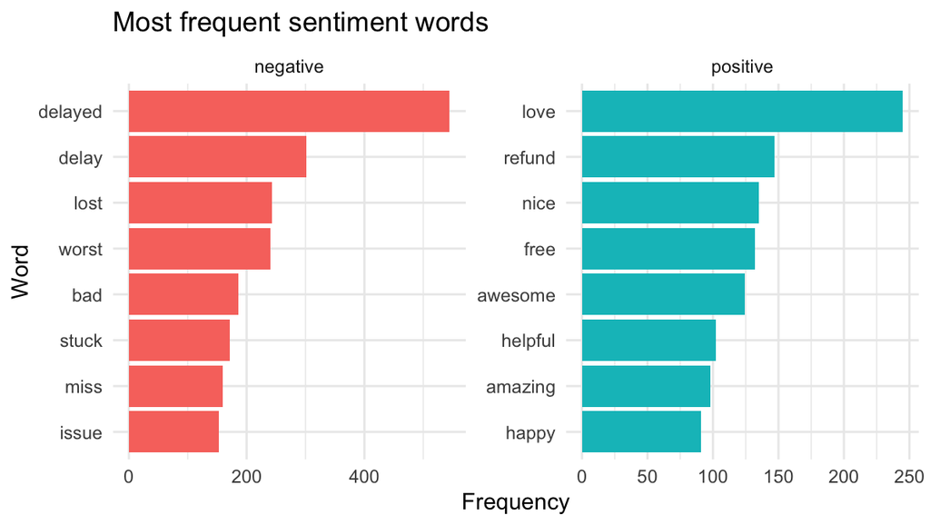

```r
top_sentiment_words |>
  mutate(word = reorder(word, n)) |>
  ggplot(aes(x = word, y = n, fill = sentiment)) +
  geom_col(show.legend = FALSE) +
  facet_wrap(~ sentiment, scales = "free") +
  coord_flip() +
  labs(
    title = "Most frequent sentiment words",
    x = "Word",
    y = "Frequency"
  ) +
  theme_minimal()
```

*Figure 3. Most frequent sentiment words identified with the Bing lexicon.*

# 11 From Analysis to Managerial Action

The final step is to translate analytical results into decisions. A manager should not only ask whether sentiment is positive or negative. A better question is: What action should this result trigger?

```r
decision_actions <- negative_reasons |>
  mutate(
    managerial_action = case_when(
      negativereason == "Customer Service Issue" ~
        "Improve support capacity.",
      negativereason == "Late Flight" ~
        "Improve delay communication.",
      negativereason == "Cancelled Flight" ~
        "Strengthen rebooking process.",
      negativereason == "Lost Luggage" ~
        "Improve baggage tracking.",
      negativereason == "Bad Flight" ~
        "Improve in-flight experience.",
      TRUE ~ "Investigate further."
    )
  )

decision_actions |>
  select(negativereason, n, managerial_action) |>
  head(8)
```

*Table 6. Managerial actions derived from negative reason categories.*

| negativereason | n | managerial_action |
| --- | --- | --- |
| Customer Service Issue | 2910 | Improve support capacity. |
| Late Flight | 1665 | Improve delay communication. |
| Can’t Tell | 1190 | Investigate further. |
| Cancelled Flight | 847 | Strengthen rebooking process. |
| Lost Luggage | 724 | Improve baggage tracking. |
| Bad Flight | 580 | Improve in-flight experience. |
| Flight Booking Problems | 529 | Investigate further. |
| Flight Attendant Complaints | 481 | Investigate further. |

This table shows how sentiment analysis can move from description to decision support. Customer service problems suggest a different response than lost luggage or delayed flights. In this sense, sentiment analysis can help managers prioritize resources.

# 12 Exercise for Students

Run the following R code and answer the question below.

```r
library(tidyverse)
library(tidytext)

customer_comments <- tibble(
  text = c(
    "The flight was delayed and the service was terrible",
    "The staff was helpful and the flight was comfortable",
    "My luggage was lost and nobody helped me"
  )
)

customer_comments |>
  unnest_tokens(word, text) |>
  anti_join(stop_words, by = "word") |>
  inner_join(get_sentiments("bing"), by = "word") |>
  count(sentiment)

# Show which words were matched as positive or negative
customer_comments |>
  unnest_tokens(word, text) |>
  anti_join(stop_words, by = "word") |>
  inner_join(get_sentiments("bing"), by = "word") |>
  select(word, sentiment) |>
  arrange(sentiment, word)
```

Question: Which managerial action would be most suitable based on the negative words in the comments?

1. Reduce the number of customer support channels
2. Improve delay communication and luggage recovery processes
3. Ignore negative comments because they are unstructured data
4. Only focus on positive words

Correct answer: B) Improve delay communication and luggage recovery processes.

# 13 Limitations

Sentiment analysis is useful, but it should not be interpreted as a perfect measurement of customer opinion. Lexicon-based approaches are simple and explainable, but they may fail when language is ironic, ambiguous, or context-dependent. Short social media posts are especially challenging because they often contain abbreviations, slang, or missing context.

For managerial decision-making, sentiment analysis should therefore be used as a support tool rather than as a replacement for human judgment. Managers should combine sentiment results with operational indicators, customer service data, and qualitative interpretation.

# 14 Conclusion

Sentiment analysis helps transform unstructured customer feedback into information that can support decision-making. In the airline example, R is used to import tweets, clean data, summarize sentiment labels, tokenize text, apply a sentiment lexicon, and connect complaint categories to managerial actions.

The main lesson is that the value of sentiment analysis is not the sentiment label itself. The value is the decision that follows from it. When text analysis identifies repeated customer pain points, managers can prioritize concrete improvements in service, communication, booking processes, or baggage handling.

**TipAffidavit**

I hereby affirm that this submitted paper was authored unaided and solely by me. Additionally, no other sources than those in the reference list were used. Parts of this paper, including tables and figures, that have been taken either verbatim or analogously from other works have in each case been properly cited with regard to their origin and authorship. This paper, either in parts or in its entirety, be it in the same or similar form, has not been submitted to any other examination board and has not been published.

I acknowledge that the university may use plagiarism detection software to check my thesis. I agree to cooperate with any investigation of suspected plagiarism and to provide any additional information or evidence requested by the university.

Checklist:

- The handout contains 3-5 pages of text.
- The submission contains the Quarto file of the handout.
- The submission contains the Quarto file of the presentation.
- The submission contains the HTML file of the handout.
- The submission contains the HTML file of the presentation.
- The submission contains the PDF file of the handout.
- The submission contains the PDF file of the presentation.
- The title page of the presentation and the handout contain personal details: name, email, and matriculation number.
- The handout contains a bibliography, created using BibTeX with an APA citation style.
- Either the handout or the presentation contains R code that proves the expertise in coding.
- The filled out Affidavit.
- The link to the presentation and the handout published on GitHub.

Mustafa Asım Ruhi, 2 June 2026, Cologne

# 15 References

Huber, S. (2025). *How to use r for data science*. https://hubchev.github.io/ds/

Liu, B. (2012). *Sentiment analysis and opinion mining*. Morgan & Claypool Publishers. https://www.cs.uic.edu/~liub/FBS/SentimentAnalysis-and-OpinionMining.pdf

Pang, B., & Lee, L. (2008). Opinion mining and sentiment analysis. *Foundations and Trends in Information Retrieval*, *2*(1–2), 1–135. https://doi.org/10.1561/1500000011

Silge, J., & Robinson, D. (2017). *Text mining with r: A tidy approach*. O’Reilly Media. https://www.tidytextmining.com/

*Twitter US airline sentiment dataset*. (2015). https://raw.githubusercontent.com/ruchitgandhi/Twitter-Airline-Sentiment-Analysis/master/Tweets.csv

Wickham, H., Cetinkaya-Rundel, M., & Grolemund, G. (2023). *R for data science: Import, tidy, transform, visualize, and model data* (2nd ed.). O’Reilly Media. https://r4ds.hadley.nz/